# Using the Semantic Priming Across Many Languages Project to Examine if Predictive Language Models Capture Human Semantic Priming

Erin M. Buchanan

Harrisburg University of Science and Technology

Addie Clark

Harrisburg University of Science and Technology

Maria Montefinese

University of Padova

## Many Thanks

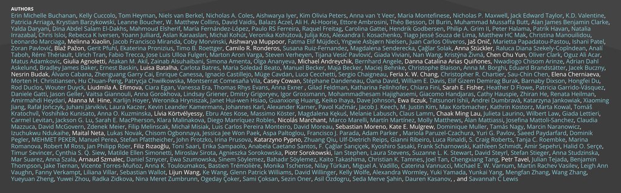

[figure not shown]

[figure not shown]

[figure not shown]

[figure not shown]

## Outline

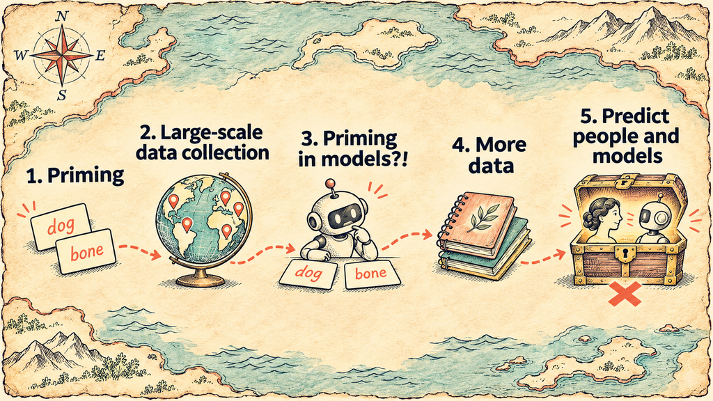

## A related word speeds up recognition

**Related pair**

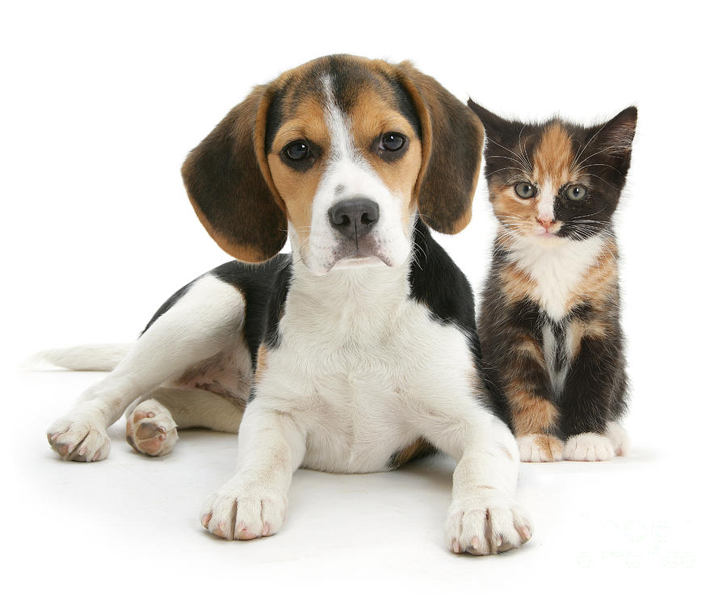

A dog and a cat

**FASTER**

**Unrelated pair**

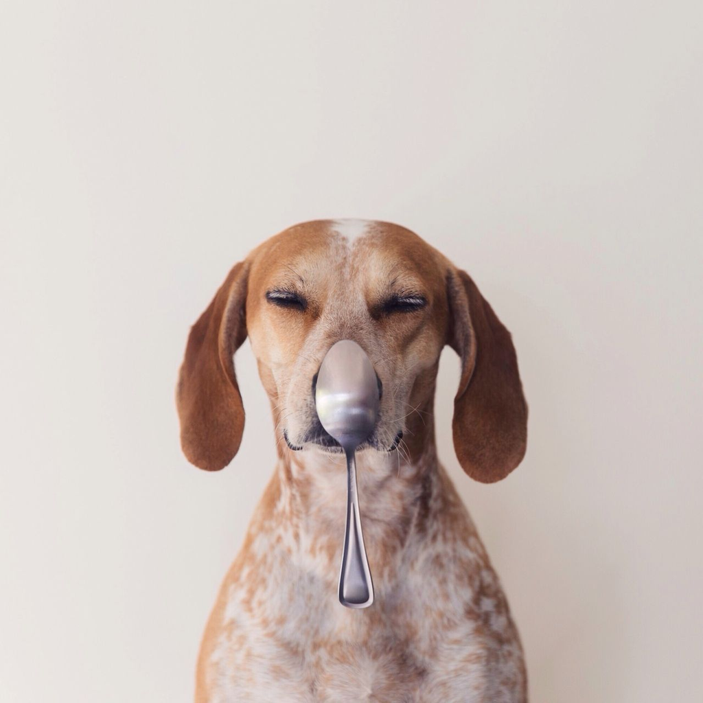

A dog and a spoon

**SLOWER**

## A quick history of semantic priming

1. 1971**Related words are recognized faster**[Meyer & Schvaneveldt](https://doi.org/10.1037/h0031564)
2. 1977**Spreading activation and expectancy**[Neely](https://eric.ed.gov/?id=EJ169109)
3. 2013**A large English benchmark**[Hutchison et al.](https://doi.org/10.3758/s13428-012-0304-z)
4. 2026**19 languages, many participants**[Buchanan et al.](https://doi.org/10.1038/s41562-025-02254-x)

*and, of course, a lot of stuff in between*

## SPAML

- 19 languages
- 25,163 participants in the analysis
- Every language showed a priming effect
- Priming was similar but did vary across languages

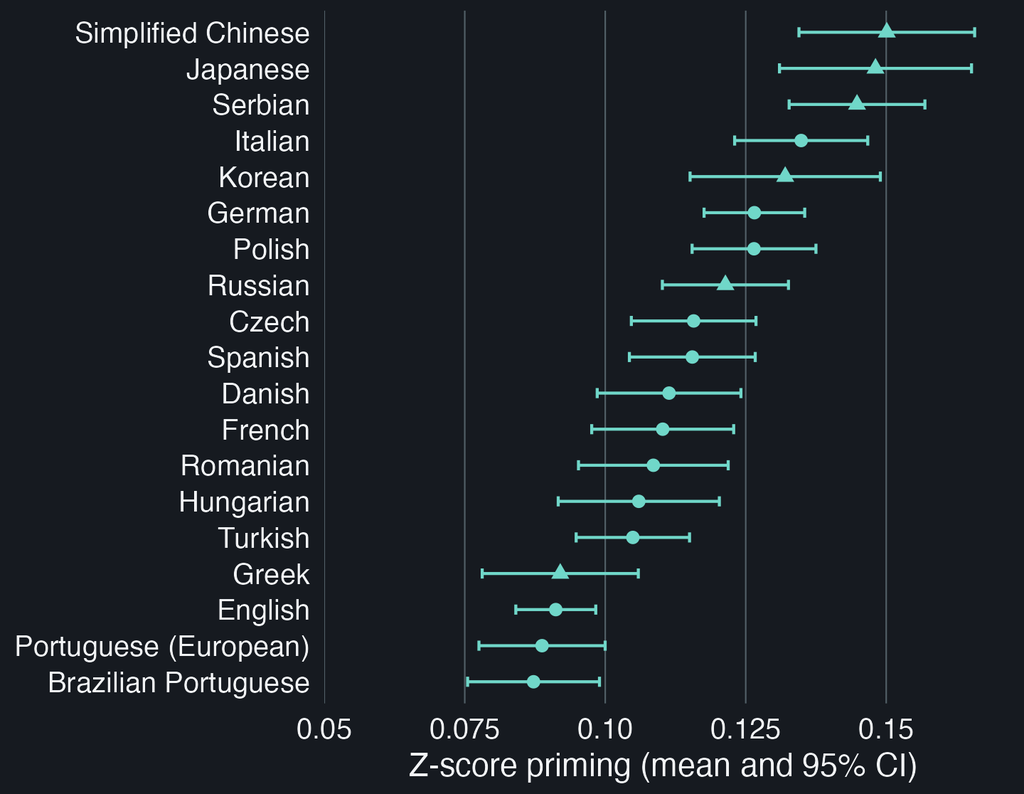

## SPAML v2 · 19 → 45 languages

Afrikaans  
Arabic  
Armenian  
Basque  
Bulgarian  
Catalan  
Croatian  
Czech  
Danish  
Dutch  
English  
Estonian  
Farsi  
Finnish  
French

Galician  
German  
Greek  
Hebrew  
Hindi  
Hungarian  
Indonesian  
Italian  
Japanese  
Korean  
Latvian  
Lithuanian  
Norwegian  
Polish  
Portuguese

Romanian  
Russian  
Serbian  
Simplified Chinese  
Slovak  
Slovenian  
Spanish  
Swedish  
Tamil  
Thai  
Traditional Chinese  
Turkish  
Ukrainian  
Urdu  
Vietnamese

Teal · New priming data

### What else can we ask about a word?

- **Age of acquisition** · When did you learn the word?
- **Familiarity** · How familiar is the word?
- **Imageability** · How easily can you picture it?
- **Concreteness** · Does it refer to something tangible?
- **Valence** · How pleasant is it?
- **Arousal** · How calming or exciting is it?

## Can we predict priming?

### In people

- Can we predict the strength of a cue-target pair?
- Item-level priming estimates can be noisy, which makes them hard to predict.

[Hutchison et al. (2008)](https://doi.org/10.1080/17470210701438111) · [Heyman et al. (2018)](https://doi.org/10.3758/s13428-018-1040-9)

### In language models

- Do LLMs show priming-like effects?
- Do the same targets get the biggest boost in people and models?
- Can we predict these effects?

## Surprisal: how unexpected is a word?

I wanted to become a **___**

doctor50%

teacher25%

pilot12.5%

table0.1%

The less probable the word, the higher its surprisal.

Used to predict [reading times (Smith & Levy, 2013)](https://doi.org/10.1016/j.cognition.2013.02.013) and [the N400 (Michaelov et al., 2024)](https://doi.org/10.1162/nol_a_00105).

## Surprisal as Priming

Unrelated cue

**table**. I wanted to become a [MASK]

Chance of PILOT: **0.75%**

Related cue

**airplane**. I wanted to become a [MASK]

Chance of PILOT: **0.86%**

Is PILOT less surprising after AIRPLANE than after TABLE?

- BERT-base on the [Misra et al. (2020)](https://doi.org/10.18653/v1/2020.findings-emnlp.415) example.
- Two times more probable for related words with minimal context.
- 1.2 times more probable for related words in more context.

## Calculating Priming

In people

RT(**cat** after bus) − RT(**cat** after dog)

Positive = faster after DOG

In models

Surprisal(**cat** after bus) − Surprisal(**cat** after dog)

Positive = more expected after DOG

Can we use the human data to show the “most aligned” priming scores?

## Prompt Sensitivity

Bare pair

dog **cat**

What people saw

Explicit frame

After the word dog, comes the word **cat**

Tells the model where the target goes

Different prompts and context will give different results, which is best?

13 models × 14 prompt setups · 182 combinations

- **Models:** GPT-2, Pythia (70M–1.4B), OLMo, Qwen, SmolLM2, BERT, RoBERTa
- **Punctuation:** dog, cat · dog and cat · Words: dog, cat
- **Frames:** Given the word dog, the next word is cat · dog makes me think of cat
- **With examples:** 2, 5, or 10 related pairs shown first

## Split-Half Validation

### Discovery set

500

Model and prompt selected by the highest Spearman correlation with human item-level priming.

### Confirmation set

500

Selected model and prompt held fixed and evaluated on new cue-target combinations.

English priming data from SPAML ([Buchanan et al., 2026](https://doi.org/10.1038/s41562-025-02254-x)).

## Discovery results

[figure not shown]

## Human and Model Priming Distributions

[figure not shown]

OLMo-1B with the After the word frame · all 1,000 English items · raw units, dashed line at zero

## Item-Level Correlation

[figure not shown]

## Semantic Priming Project Validation

[figure not shown]

The correlations were modest at both SOAs and association types.

Human data from [Hutchison et al. (2013)](https://doi.org/10.3758/s13428-012-0304-z).

## Model and Language Match: A 2 × 2 Test

English model · English words

After the word **dog**, comes the word **cat**

Matched: expected to work

English model · German words

After the word **Hund**, comes the word **Katze**

Mismatched: expected to work poorly

German model · English words

Nach dem Wort **dog** kommt das Wort **cat**

Mismatched: expected to work poorly

German model · German words

Nach dem Wort **Hund** kommt das Wort **Katze**

Matched: expected to work

- Examine the impact of trained model language matched to tested language
- Not a perfect comparison as most models use sub-word input units

## English and German Priming

[figure not shown]

Models show an average priming effect but only modestly track people item by item, even when the model matches the language. Prompt and tokenization didn’t fix it either, so models may “prime” differently or our measure may not capture the human effect.

## Ukrainian Pilot Data

[figure not shown]

## Predicting Human and Model Priming

Human priming

**Linguistic:** length, frequency, orthographic neighborhood, bigram frequency, Levenshtein distance

**Subjective:** age of acquisition, imageability, concreteness, valence, arousal, familiarity

**Similarity:** cue–target similarity from language models

**Participants:** age, gender, education, native language

Model priming

**Outcome:** each pair’s surprisal-based priming score from the model

**Predictors:** the same linguistic, subjective and similarity variables

**Compare:** which variables predict human priming and which predict model priming, across models and prompts

Two prediction problems to cleanly separate human and model results.

## Broad Goals

Human cognition

- Which properties of words and pairs drive semantic priming
- Whether those predictors hold across languages

Model architecture

- Which properties of words and pairs drive model priming
- Whether the same predictors drive models and people
- Theories of semantic memory: does association, co-occurrence or shared features account for the weight between concepts?
- Universal versus language-specific predictors: which item-level predictors hold across languages and writing systems?
- Network structure: do the same word and pair properties shape spreading activation across the lexicon, in people and in language models?

## Thanks and Questions

Thank you to the researchers, translators, and participants of the Semantic Priming Across Many Languages project.

Please join us!

Code and slides at github.com/SemanticPriming/priming-llms

[figure not shown]

semanticpriming@harrisburgu.edu

## References

Buchanan, E. M., Cuccolo, K., Heyman, T., van Berkel, N., Coles, N. A., Iyer, A., Peters, K., van ’t Veer, A. E., Montefinese, M., Maxwell, N. P., Taylor, J. E., Valentine, K. D., Arriaga, P., Barzykowski, K., Boucher, L., Collins, W. M., Vaidis, D. C., Aczel, B., Al-Hoorie, A. H., … Lewis, S. C. (2026). Measuring the semantic priming effect across many languages. *Nature Human Behaviour*, *10*(1), 182–201. https://doi.org/10.1038/s41562-025-02254-x

Heyman, T., Bruninx, A., Hutchison, K. A., & Storms, G. (2018). The (un)reliability of item-level semantic priming effects. *Behavior Research Methods*, *50*, 2173–2183. https://doi.org/10.3758/s13428-018-1040-9

Hutchison, K. A., Balota, D. A., Cortese, M. J., & Watson, J. M. (2008). Predicting semantic priming at the item level. *Quarterly Journal of Experimental Psychology*, *61*(7), 1036–1066. https://doi.org/10.1080/17470210701438111

Hutchison, K. A., Balota, D. A., Neely, J. H., Cortese, M. J., Cohen-Shikora, E. R., Tse, C.-S., Yap, M. J., Bengson, J. J., Niemeyer, D., & Buchanan, E. (2013). The semantic priming project. *Behavior Research Methods*, *45*(4), 1099–1114. https://doi.org/10.3758/s13428-012-0304-z

Meyer, D. E., & Schvaneveldt, R. W. (1971). Facilitation in recognizing pairs of words: Evidence of a dependence between retrieval operations. *Journal of Experimental Psychology*, *90*(2), 227–234. https://doi.org/10.1037/h0031564

Michaelov, J. A., Bardolph, M. D., Van Petten, C. K., Bergen, B. K., & Coulson, S. (2024). Strong prediction: Language model surprisal explains multiple N400 effects. *Neurobiology of Language*, *5*(1), 107–135.

Misra, K., Ettinger, A., & Rayz, J. (2020). Exploring BERT’s sensitivity to lexical cues using tests from semantic priming. *Findings of the Association for Computational Linguistics: EMNLP 2020*, 4625–4635.

Neely, J. H. (1977). Semantic priming and retrieval from lexical memory: Roles of inhibitionless spreading activation and limited-capacity attention. *Journal of Experimental Psychology: General*, *106*(3), 226–254.

Smith, N. J., & Levy, R. (2013). The effect of word predictability on reading time is logarithmic. *Cognition*, *128*(3), 302–319. https://doi.org/10.1016/j.cognition.2013.02.013